# Tutorial solutions

## Week 4: Tutorial solutions

#### Import Packages

```python
import pandas as pd
from sklearn import datasets
from sklearn.metrics import accuracy_score
from sklearn.preprocessing import StandardScaler
from sklearn.model_selection import train_test_split

from sklearn.decomposition import PCA
from sklearn.neighbors import KNeighborsClassifier
from sklearn.feature_selection import chi2, mutual_info_classif, SelectKBest
```

```python
# import wine dataset that is given by scikit-learn, 'as_frame=True' ensures to return the data as a dataframe
wine = datasets.load_wine(as_frame=True)
# Describes the dataset
print(wine.DESCR)
```

```
.. _wine_dataset:

Wine recognition dataset
------------------------

**Data Set Characteristics:**

    :Number of Instances: 178 (50 in each of three classes)
    :Number of Attributes: 13 numeric, predictive attributes and the class
    :Attribute Information:
 		- Alcohol
 		- Malic acid
 		- Ash
		- Alcalinity of ash
 		- Magnesium
		- Total phenols
 		- Flavanoids
 		- Nonflavanoid phenols
 		- Proanthocyanins
		- Color intensity
 		- Hue
 		- OD280/OD315 of diluted wines
 		- Proline

    - class:
            - class_0
            - class_1
            - class_2

    :Summary Statistics:

    ============================= ==== ===== ======= =====
                                   Min   Max   Mean     SD
    ============================= ==== ===== ======= =====
    Alcohol:                      11.0  14.8    13.0   0.8
    Malic Acid:                   0.74  5.80    2.34  1.12
    Ash:                          1.36  3.23    2.36  0.27
    Alcalinity of Ash:            10.6  30.0    19.5   3.3
    Magnesium:                    70.0 162.0    99.7  14.3
    Total Phenols:                0.98  3.88    2.29  0.63
```

[output cut: 40 more lines]

```
  Tech. Rep. no. 92-02, (1992), Dept. of Computer Science and Dept. of
  Mathematics and Statistics, James Cook University of North Queensland.
  (Also submitted to Technometrics).

  The data was used with many others for comparing various
  classifiers. The classes are separable, though only RDA
  has achieved 100% correct classification.
  (RDA : 100%, QDA 99.4%, LDA 98.9%, 1NN 96.1% (z-transformed data))
  (All results using the leave-one-out technique)

  (2) S. Aeberhard, D. Coomans and O. de Vel,
  "THE CLASSIFICATION PERFORMANCE OF RDA"
  Tech. Rep. no. 92-01, (1992), Dept. of Computer Science and Dept. of
  Mathematics and Statistics, James Cook University of North Queensland.
  (Also submitted to Journal of Chemometrics).
```

```python
X = wine.data
print(f"The dataset contains {X.shape[0]} samples and "f"{X.shape[1]} features")
X.head()
```

```
The dataset contains 178 samples and 13 features
```

|  | alcohol | malic_acid | ash | alcalinity_of_ash | magnesium | total_phenols | flavanoids | nonflavanoid_phenols | proanthocyanins | color_intensity | hue | od280/od315_of_diluted_wines | proline |
| --- | --- | --- | --- | --- | --- | --- | --- | --- | --- | --- | --- | --- | --- |
| 0 | 14.23 | 1.71 | 2.43 | 15.6 | 127.0 | 2.80 | 3.06 | 0.28 | 2.29 | 5.64 | 1.04 | 3.92 | 1065.0 |
| 1 | 13.20 | 1.78 | 2.14 | 11.2 | 100.0 | 2.65 | 2.76 | 0.26 | 1.28 | 4.38 | 1.05 | 3.40 | 1050.0 |
| 2 | 13.16 | 2.36 | 2.67 | 18.6 | 101.0 | 2.80 | 3.24 | 0.30 | 2.81 | 5.68 | 1.03 | 3.17 | 1185.0 |
| 3 | 14.37 | 1.95 | 2.50 | 16.8 | 113.0 | 3.85 | 3.49 | 0.24 | 2.18 | 7.80 | 0.86 | 3.45 | 1480.0 |
| 4 | 13.24 | 2.59 | 2.87 | 21.0 | 118.0 | 2.80 | 2.69 | 0.39 | 1.82 | 4.32 | 1.04 | 2.93 | 735.0 |

```python
X.describe().T
```

|  | count | mean | std | min | 25% | 50% | 75% | max |
| --- | --- | --- | --- | --- | --- | --- | --- | --- |
| alcohol | 178.0 | 13.000618 | 0.811827 | 11.03 | 12.3625 | 13.050 | 13.6775 | 14.83 |
| malic_acid | 178.0 | 2.336348 | 1.117146 | 0.74 | 1.6025 | 1.865 | 3.0825 | 5.80 |
| ash | 178.0 | 2.366517 | 0.274344 | 1.36 | 2.2100 | 2.360 | 2.5575 | 3.23 |
| alcalinity_of_ash | 178.0 | 19.494944 | 3.339564 | 10.60 | 17.2000 | 19.500 | 21.5000 | 30.00 |
| magnesium | 178.0 | 99.741573 | 14.282484 | 70.00 | 88.0000 | 98.000 | 107.0000 | 162.00 |
| total_phenols | 178.0 | 2.295112 | 0.625851 | 0.98 | 1.7425 | 2.355 | 2.8000 | 3.88 |
| flavanoids | 178.0 | 2.029270 | 0.998859 | 0.34 | 1.2050 | 2.135 | 2.8750 | 5.08 |
| nonflavanoid_phenols | 178.0 | 0.361854 | 0.124453 | 0.13 | 0.2700 | 0.340 | 0.4375 | 0.66 |
| proanthocyanins | 178.0 | 1.590899 | 0.572359 | 0.41 | 1.2500 | 1.555 | 1.9500 | 3.58 |
| color_intensity | 178.0 | 5.058090 | 2.318286 | 1.28 | 3.2200 | 4.690 | 6.2000 | 13.00 |
| hue | 178.0 | 0.957449 | 0.228572 | 0.48 | 0.7825 | 0.965 | 1.1200 | 1.71 |
| od280/od315_of_diluted_wines | 178.0 | 2.611685 | 0.709990 | 1.27 | 1.9375 | 2.780 | 3.1700 | 4.00 |
| proline | 178.0 | 746.893258 | 314.907474 | 278.00 | 500.5000 | 673.500 | 985.0000 | 1680.00 |

```python
y = wine.target
y.head()
```

```
0    0
1    0
2    0
3    0
4    0
Name: target, dtype: int64
```

```python
y.value_counts()
```

```
1    71
0    59
2    48
Name: target, dtype: int64
```

```python
X_train, X_test, y_train, y_test = train_test_split(X, y, random_state=1)
```

```python
# Refer to https://scikit-learn.org/stable/modules/classes.html#module-sklearn.preprocessing for preprocessing data
scaler = StandardScaler()
X_train_scaled = pd.DataFrame(scaler.fit_transform(X_train.values), index=X_train.index, columns=X_train.columns)
X_train_scaled.head(2)
```

|  | alcohol | malic_acid | ash | alcalinity_of_ash | magnesium | total_phenols | flavanoids | nonflavanoid_phenols | proanthocyanins | color_intensity | hue | od280/od315_of_diluted_wines | proline |
| --- | --- | --- | --- | --- | --- | --- | --- | --- | --- | --- | --- | --- | --- |
| 44 | 0.093977 | -0.557879 | -0.957529 | -0.812987 | 0.602004 | 1.180371 | 1.021742 | -0.743746 | 0.801107 | 0.000157 | -0.332934 | 1.081639 | 0.471259 |
| 78 | -0.815037 | -1.226791 | -1.506457 | -1.489936 | 2.718621 | -0.567133 | -0.121876 | -0.158431 | 2.052185 | -0.686666 | 0.432278 | -0.366970 | 0.024107 |

```python
X_test_scaled = pd.DataFrame(scaler.transform(X_test.values), index=X_test.index, columns=X_test.columns)
X_test_scaled.head(2)
```

|  | alcohol | malic_acid | ash | alcalinity_of_ash | magnesium | total_phenols | flavanoids | nonflavanoid_phenols | proanthocyanins | color_intensity | hue | od280/od315_of_diluted_wines | proline |
| --- | --- | --- | --- | --- | --- | --- | --- | --- | --- | --- | --- | --- | --- |
| 161 | 0.901989 | 0.719916 | 0.652660 | 0.110126 | 0.602004 | -0.678337 | -1.404717 | 1.095816 | -1.306873 | 0.351945 | 0.007160 | -1.049487 | -0.20775 |
| 117 | -0.701410 | -0.695092 | -0.628172 | 0.879386 | 0.674991 | -0.408269 | 0.116792 | -0.242048 | 0.081309 | -1.247851 | 0.432278 | 0.538411 | -1.31735 |

#### Tutorial 4A (Part A):

**1. Apply other conditions of IG based on lecture and compare the performance of the model when applied to mutual_info_classif.**

#### a. Select top 50% of the features

```python
i_scores = mutual_info_classif(X_train_scaled,y_train)

# put the i_scores in a dataframe and sort
features_info_gain = pd.DataFrame(i_scores,index = X_train_scaled.columns, columns =['I-Gain'])
features_info_gain.sort_values(by=['I-Gain'],ascending=False,inplace=True)
features_info_gain
```

|  | I-Gain |
| --- | --- |
| flavanoids | 0.704646 |
| proline | 0.614764 |
| color_intensity | 0.535434 |
| od280/od315_of_diluted_wines | 0.498046 |
| hue | 0.497069 |
| total_phenols | 0.442139 |
| alcohol | 0.386322 |
| malic_acid | 0.334877 |
| proanthocyanins | 0.236884 |
| alcalinity_of_ash | 0.208526 |
| magnesium | 0.155987 |
| ash | 0.115841 |
| nonflavanoid_phenols | 0.096093 |

```python
# Generate top 50% of the features of the dataframes and produce the corresponding X (numpy) arrays

top_50pc_features= X_train_scaled[features_info_gain.index[:int(features_info_gain.shape[0]/2)]]
```

```python
model = KNeighborsClassifier()
```

```python
model.fit(X_train_scaled, y_train)

y_predicted = model.predict(X_test_scaled)
print("Accuracy of the model trained on the top 50% features: ", accuracy_score(y_test, y_predicted))
```

```
Accuracy of the model trained on the top 50% features:  0.9777777777777777
```

#### b. IG > 50% of max IG score

```python
features_IG_above_50pc = features_info_gain[features_info_gain['I-Gain'] > (features_info_gain['I-Gain'].max() * 0.5)]
features_IG_above_50pc
```

|  | I-Gain |
| --- | --- |
| flavanoids | 0.704646 |
| proline | 0.614764 |
| color_intensity | 0.535434 |
| od280/od315_of_diluted_wines | 0.498046 |
| hue | 0.497069 |
| total_phenols | 0.442139 |
| alcohol | 0.386322 |

```python
top_IG_features_train = X_train_scaled[features_IG_above_50pc.index]
top_IG_features_test = X_test_scaled[features_IG_above_50pc.index]
```

```python
model.fit(X_train_scaled, y_train)

y_predicted = model.predict(X_test_scaled)
print("Accuracy of the model trained on the top 50% features: ", accuracy_score(y_test, y_predicted))
```

```
Accuracy of the model trained on the top 50% features:  0.9777777777777777
```

We observe that features with IG > 50% of max IG score yield maximum accuracy score of the three conditions (top k features, top 50% of features and features with IG > 50% of max IG) considered.

**2. Choose the top features for k-NN using the chi-sq statistics and SelectKBest**

```python
# using X instead of X_transformed as fit_transform expects the values of X to be non-negative.
kbest = SelectKBest(chi2, k=3)
X_train_kbest = kbest.fit_transform(X_train, y_train)
X_test_kbest = kbest.transform(X_test)

model.fit(X_train_kbest, y_train)

y_predicted = model.predict(X_test_kbest)
print("Accuracy of the model trained on features selected using chi-sq: ", accuracy_score(y_test, y_predicted))
```

```
Accuracy of the model trained on features selected using chi-sq:  0.6666666666666666
```

#### Tutorial 4A (Part B):

**1. Perform sequential backward selection.**

```python
from mlxtend.feature_selection import SequentialFeatureSelector as SFS
from mlxtend.plotting import plot_sequential_feature_selection as plot_sfs
knn = KNeighborsClassifier(n_neighbors=5)
```

```python
sfs_backward = SFS(knn,
                  k_features="best",
                  forward=False,
                  floating=False,
                  scoring='accuracy',
                  cv=5)

# try the sfs_forward model on the
sfs_backward = sfs_backward.fit(X_train_scaled, y_train)
```

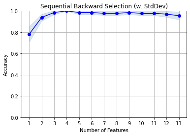

```
('alcohol', 'flavanoids', 'color_intensity', 'proline')
```

```python
from mlxtend.plotting import plot_sequential_feature_selection as plot_sfs
import matplotlib.pyplot as plt

fig1 = plot_sfs(sfs_backward.get_metric_dict(), ylabel='Accuracy')

plt.ylim([0, 1])
plt.title('Sequential Backward Selection (w. StdDev)')
plt.grid()
plt.show()
print(sfs_backward.k_feature_names_)
```

```python
pd.DataFrame.from_dict(sfs_backward.get_metric_dict()).T
```

|  | feature_idx | cv_scores | avg_score | feature_names | ci_bound | std_dev | std_err |
| --- | --- | --- | --- | --- | --- | --- | --- |
| 13 | (0, 1, 2, 3, 4, 5, 6, 7, 8, 9, 10, 11, 12) | [0.9629629629629629, 0.8888888888888888, 0.962... | 0.955271 | (alcohol, malic_acid, ash, alcalinity_of_ash, ... | 0.0465725 | 0.036235 | 0.0181175 |
| 12 | (0, 1, 2, 3, 5, 6, 7, 8, 9, 10, 11, 12) | [1.0, 0.9259259259259259, 0.9629629629629629, ... | 0.970085 | (alcohol, malic_acid, ash, alcalinity_of_ash, ... | 0.0357283 | 0.0277979 | 0.0138989 |
| 11 | (0, 1, 2, 3, 6, 7, 8, 9, 10, 11, 12) | [1.0, 0.9629629629629629, 0.9629629629629629, ... | 0.977493 | (alcohol, malic_acid, ash, alcalinity_of_ash, ... | 0.0236292 | 0.0183843 | 0.00919217 |
| 10 | (0, 1, 2, 3, 6, 7, 8, 9, 10, 12) | [1.0, 0.9629629629629629, 0.9629629629629629, ... | 0.977493 | (alcohol, malic_acid, ash, alcalinity_of_ash, ... | 0.0236292 | 0.0183843 | 0.00919217 |
| 9 | (0, 1, 2, 6, 7, 8, 9, 10, 12) | [1.0, 1.0, 0.9629629629629629, 1.0, 0.96153846... | 0.9849 | (alcohol, malic_acid, ash, flavanoids, nonflav... | 0.0237763 | 0.0184988 | 0.00924939 |
| 8 | (0, 1, 6, 7, 8, 9, 10, 12) | [0.9629629629629629, 0.9629629629629629, 0.962... | 0.977778 | (alcohol, malic_acid, flavanoids, nonflavanoid... | 0.0233208 | 0.0181444 | 0.00907218 |
| 7 | (0, 1, 6, 7, 9, 10, 12) | [0.9629629629629629, 0.9629629629629629, 0.962... | 0.977778 | (alcohol, malic_acid, flavanoids, nonflavanoid... | 0.0233208 | 0.0181444 | 0.00907218 |
| 6 | (0, 1, 6, 7, 9, 12) | [0.9629629629629629, 1.0, 0.9629629629629629, ... | 0.985185 | (alcohol, malic_acid, flavanoids, nonflavanoid... | 0.0233208 | 0.0181444 | 0.00907218 |
| 5 | (0, 1, 6, 9, 12) | [1.0, 0.9629629629629629, 0.9629629629629629, ... | 0.985185 | (alcohol, malic_acid, flavanoids, color_intens... | 0.0233208 | 0.0181444 | 0.00907218 |
| 4 | (0, 6, 9, 12) | [1.0, 1.0, 1.0, 1.0, 1.0] | 1 | (alcohol, flavanoids, color_intensity, proline) | 0 | 0 | 0 |
| 3 | (6, 9, 12) | [0.9629629629629629, 0.9629629629629629, 1.0, ... | 0.985185 | (flavanoids, color_intensity, proline) | 0.0233208 | 0.0181444 | 0.00907218 |
| 2 | (6, 9) | [0.9629629629629629, 0.9629629629629629, 0.962... | 0.939316 | (flavanoids, color_intensity) | 0.0403729 | 0.0314115 | 0.0157057 |
| 1 | (6,) | [0.8888888888888888, 0.8148148148148148, 0.666... | 0.781766 | (flavanoids,) | 0.0929145 | 0.0722906 | 0.0361453 |

**2. Select cv = 10 and k_features = 7 for sequential forward selection and sequential backward selection. Identify the common features from feature set with highest accuracy score in each case.**

```python
knn = KNeighborsClassifier(n_neighbors=5)
```

```python
sfs_forward = SFS(knn, k_features=7,  forward=True, floating=False, scoring='accuracy', cv=10)

# try the sfs_forward model on the
sfs_forward = sfs_forward.fit(pd.concat([X_train_scaled, X_test_scaled]), pd.concat([y_train, y_test]))
```

```python
sfs_backward = SFS(knn, k_features=7, forward=True, floating=False, scoring='accuracy', cv=10)

# try the sfs_forward model on the
sfs_backward = sfs_backward.fit(pd.concat([X_train_scaled, X_test_scaled]), pd.concat([y_train, y_test]))
```

```python
b5_feat = sfs_backward.k_feature_names_
f5_feat = sfs_forward.k_feature_names_
print('Backward SFS Features: ', b5_feat)
print('\nForward SFS Features: ', f5_feat)
print('\nCommon features: ', (set(b5_feat).intersection(set(f5_feat))))
```

```
Backward SFS Features:  ('alcohol', 'malic_acid', 'magnesium', 'total_phenols', 'flavanoids', 'hue', 'proline')

Forward SFS Features:  ('alcohol', 'malic_acid', 'magnesium', 'total_phenols', 'flavanoids', 'hue', 'proline')

Common features:  {'magnesium', 'flavanoids', 'alcohol', 'hue', 'proline', 'malic_acid', 'total_phenols'}
```

#### Tutorial 4B :

**1. Load the wine dataset. Perform PCA. How much of the variance is explained by the first 3 principal components?**

```python
#Normalize the input features
scaler = StandardScaler()
X_train_scaled = scaler.fit_transform(X_train)
X_test_scaled = scaler.transform(X_test)

pca = PCA(n_components=4)
X_train_transformed = pca.fit(X_train_scaled).transform(X_train_scaled)
X_test_transformed = pca.transform(X_test_scaled)

# Proportion of variance explained for each components
print("Variance explained by each of the principal components: ", pca.explained_variance_ratio_)
```

```
Variance explained by each of the principal components:  [0.35623588 0.19406282 0.11367336 0.07738114]
```

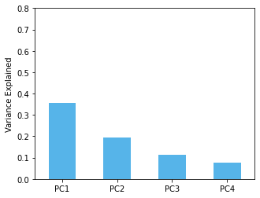

```python
df = pd.DataFrame(pca.explained_variance_ratio_,
                  index=['PC1','PC2','PC3','PC4'],columns =['var'])

plot = df.plot.bar(figsize=(5,4), color='#56B4E9', rot=0)
plot.set_ylabel("Variance Explained")
plot.set_ylim([0,0.8])
plot.get_legend().remove();
```

The variance explained by the first 3 principal components are ~36%, 19% and 11%

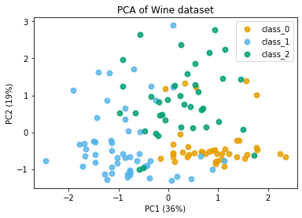

```python
plt.figure()
colors = ['#E69F00', '#56B4E9', '#009E73']
lw = 2

for color, i, target_name in zip(colors, [0, 1, 2], wine.target_names):
    plt.scatter(X_train_scaled[y_train == i, 0],
                X_train_scaled[y_train == i, 1], color=color, alpha=.8, lw=lw,
                label=target_name)
plt.legend(loc='best', shadow=False, scatterpoints=1)
plt.xlabel('PC1 (36%)')
plt.ylabel('PC2 (19%)')
plt.title('PCA of Wine dataset')

plt.show()
```

**2. What is the accuracy of the KNeighborsClassifier on the transformed data? How does it compare to the accuracy obtained through feature selection?**

```python
knn_model = KNeighborsClassifier()

knn_model.fit(X_train_scaled, y_train)
y_predicted = knn_model.predict(X_test_scaled)
accuracy_score(y_predicted, y_test)
```

```
0.9777777777777777
```

**Summary of the accuracy obtained through different methods of dimensionality reduction on wine dataset:**

top 3 features chosen from IG : 93.33% (in tutorial 4A)  
top 50% of the features based on IG : 97.7%  
IG > 0.5*(max IG) : 97.7%

top 3 features chosen from chi-sq : 66.66%

Overall, IG > 0.5*(max IG), IG > 0.5*(max IG) and PCA gave the best accuracy of the model on wine dataset.

**Note:** Not considering wrapper methods as evaluation was based on cross-validation which will be discussed in the next week.